# TensorFlow による 3LP MNIST 実習 ハンズオン資料

2016/04/16 機械学習 名古屋 第3回勉強会

## はじめに

- この資料は、TensorFlow を用いて、3LP（3層パーセプトロン）により MNIST の学習を実施することを目的とするものです。
- この資料に掲載のコードは、本日の読書会の資料（[第2章](http://antimon2.github.io/MLNGY_201604/slides/Chapter2_FeedforwardNeuralNetwork.slides.html)・[第3章](http://antimon2.github.io/MLNGY_201604/slides/Chapter3_StochasticGradientDescent.slides.html)）、および TensorFlow 公式のチュートリアル [MNIST For ML Beginners](https://www.tensorflow.org/versions/master/tutorials/mnist/beginners/) を元に構築しております。

## 目標

- TensorFlow を用いた基本的な DeepLearning を自分で書ける。
- 正則化や、学習係数・モメンタム等の工夫を加えて、学習の精度を上げる（オプション、もしくは宿題）

## 環境等

以下の環境を前提とします。

- Python（必須）（2.7.x / 3.x どちらでもOK）
- TensorFlow（必須）（0.6 / 0.7 / 0.8[New!] どれでもOK）
- matplotlib（任意、結果を確認する際に利用）
- IPython（任意）

## TensorFlow

- [公式サイト](https://www.tensorflow.org/)
- Google 製の「データフローグラフを用いた数値計算ライブラリ」（公式の説明を私訳）
  - DeepLearning 用の機能も豊富。
- つい先日 [v0.8がリリース(2016/04/13)](http://googleresearch.blogspot.com/2016/04/announcing-tensorflow-08-now-with.html)

インストールの詳細省略。  
インストールが成功していれば、Python のインタラクティブシェル（もしくは ipython, Jupyter 等）で↓以下のようにすれば利用開始。

```python
import tensorflow as tf
```

## MNIST

- 機械学習定番の、多クラス分類（教師あり学習）問題「手書き数字認識」のサンプルデータ。
- 多くの機械学習ライブラリで、手軽に体験できるよう「MNIST をロードする関数（またはサンプル）」が用意されている。

TensorFlow では、以下のようにすると MNIST データセット（訓練データおよびテストデータ）を扱えるようになる：

```python
from tensorflow.examples.tutorials.mnist import input_data
mnist = input_data.read_data_sets("MNIST_data/", one_hot=True)
```

```
Extracting MNIST_data/train-images-idx3-ubyte.gz
Extracting MNIST_data/train-labels-idx1-ubyte.gz
Extracting MNIST_data/t10k-images-idx3-ubyte.gz
Extracting MNIST_data/t10k-labels-idx1-ubyte.gz
```

## 3LP 構築

### 訓練データ（及び正解データ）用の変数（プレースホルダ）用意

```python
# 訓練データ：長さ784のベクトルデータ(=28x28 の画像データ)
x = tf.placeholder(tf.float32, [None, 784])
# 正解データ：長さ10のベクトルデータ(0,1,…,9 の対応する要素のみ 1、他は 0)
d = tf.placeholder(tf.float32, [None, 10])
```

### 第1層

```python
W1 = tf.Variable(tf.random_normal([784, 128], mean=0.0, stddev=0.05))
b1 = tf.Variable(tf.zeros([128]))
z1 = tf.nn.relu(tf.matmul(x,  W1) + b1)
```

### 第2層

```python
W2 = tf.Variable(tf.random_normal([128, 64], mean=0.0, stddev=0.05))
b2 = tf.Variable(tf.zeros([64]))
z2 = tf.nn.relu(tf.matmul(z1, W2) + b2)
```

### 第3層（出力層）

```python
W3 = tf.Variable(tf.random_normal([64, 10], mean=0.0, stddev=0.05))
b3 = tf.Variable(tf.zeros([10]))
y  = tf.nn.softmax(tf.matmul(z2, W3) + b3)
```

### 誤差関数（＝交差エントロピー）

```python
x_entropy = -tf.reduce_sum(d * tf.log(y))
```

### 最適化（＝確率的勾配降下法）

- 以下では `tf.train.GradientDescentOptimizer` を利用した例を示す。
  - 引数（＝学習係数）は 0.01
- 他に、`tf.train.AdagradOptimizer`、`tf.train.MomentumOptimizer` 等を利用しても良い。

```python
optimizer = tf.train.GradientDescentOptimizer(0.01)
train_step = optimizer.minimize(x_entropy)
```

## 学習

### TensorFlow による学習の流れ

1. 変数の初期化
2. セッションの開始
3. ミニバッチを利用した学習ステップのループ
4. （オプション）精度の確認
5. （オプション）推測結果確認

### 1. 変数の初期化

```python
init = tf.initialize_all_variables()
```

### 2. セッションの開始

```python
sess = tf.Session()
sess.run(init)
# ↑実際にはここで始めて各変数が初期化される
```

### 2.5. （先に）精度の確認（の準備）

今回は分かりやすくするため、ループ中にも随時精度を確認してみる。  
そのため先に精度を確認する各種準備。

```python
# y（＝学習結果の出力）と d（正解データ）で一致しているかどうかを確認
correct_prediction = tf.equal(tf.argmax(y, 1), tf.argmax(d, 1))
# 平均（＝一致している個数÷全データ数）を計算
accuracy = tf.reduce_mean(tf.cast(correct_prediction, tf.float32))
```

### 3. ミニバッチを利用した学習ステップのループ

```python
# ループ回数は 2000回
# バッチサイズは 100
# 200イテレーションごとに現在の精度を算出し出力
for i in range(1, 2001):
    batch_xs, batch_ys = mnist.train.next_batch(100)
    sess.run(train_step, feed_dict={x: batch_xs, d: batch_ys})
    if i % 200 == 0:
        train_accuracy = sess.run(accuracy, feed_dict={x: batch_xs, d: batch_ys})
        print('  step, accurary = %6d: %6.3f' % (i, train_accuracy))
```

```
  step, accurary =    200:  0.820
  step, accurary =    400:  0.980
  step, accurary =    600:  0.980
  step, accurary =    800:  0.990
  step, accurary =   1000:  1.000
  step, accurary =   1200:  0.990
  step, accurary =   1400:  1.000
  step, accurary =   1600:  1.000
  step, accurary =   1800:  0.980
  step, accurary =   2000:  1.000
```

### 4. 精度の確認

テストデータを利用して精度の確認。

```python
print(sess.run(accuracy, feed_dict={x: mnist.test.images, d: mnist.test.labels}))
```

```
0.9652
```

↑だいたい0.96前後になる（と思われます）。

### 5. 推測結果の確認

matplotlib が入っている場合、以下を実行して実際のデータと推測結果を確認してみる。

```python
%matplotlib inline
# ↑Jupyter 上で実行するときに必要

import matplotlib
import numpy as np
import matplotlib.pyplot as plt
import matplotlib.cm as cm
import random
```

```
Classified as: 7
```

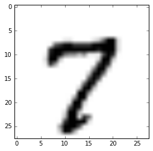

```python
n = len(mnist.test.images)
i = random.randrange(n)

imageData = mnist.test.images[i]
label = mnist.test.labels[i]

result = sess.run(y, feed_dict={x: [imageData], d: [label]})
print("Classified as: %d" % np.argmax(result))

image = np.reshape(imageData, [28, 28])

plt.imshow(image, cmap = cm.Greys)
# plt.show()
# ↑Jupyter 以外では必要
```

## 発展

### さらなる精度向上のためにできること

- イテレーション回数を調整する
  - TensorBoard を利用するか、自分で matplotlib を用いるなどして学習曲線を引く
- 層を増やしてみる（4層、5層、…）
- 各層のユニット数（サイズ）を変えてみる
- 学習係数を変更してみる
- 正則化項を追加してみる
- `tf.train.GradientDescentOptimizer` の代わりに、`tf.train.AdagradOptimizer` や `tf.train.MomentumOptimizer` を試してみる。
  - `optimizer = tf.train.MomentumOptimizer(0.1, 0.9)` とするだけでもかなり変わる（はず）
- **CNN に手を出してみる**
  - 次回は↑をやる予定。